# Summary

David T. Callaghan

06 December, 2016

## Cluster Frequency Over Time

I created a frequency per individual plot of spawning clusters which nicely scaled the data among years. Each year has a nice spawning bump in the middle of September.

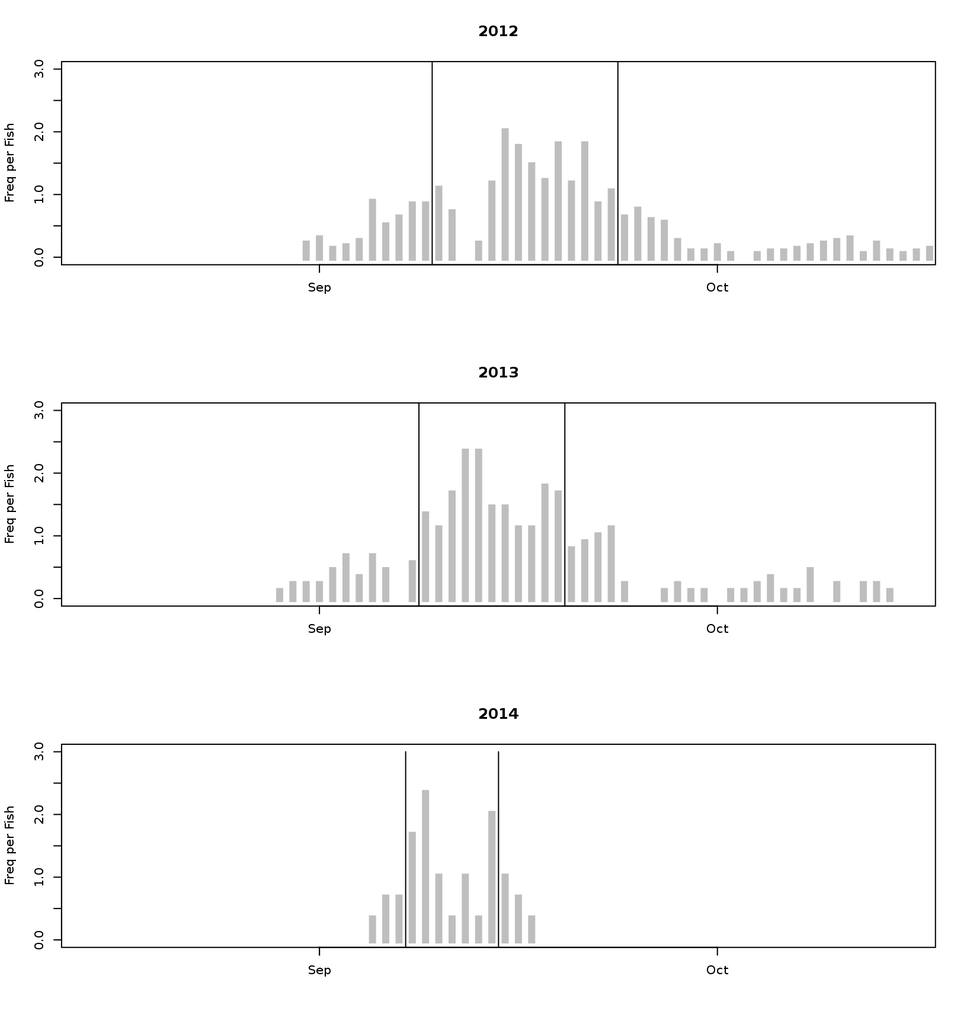

## Spawning Shoal Use

Below is a bubble pie plot showing cumulative frequency of use for all years (bubble size) and relative use among years (pie slices). It’s a bit messy but fun to look at!

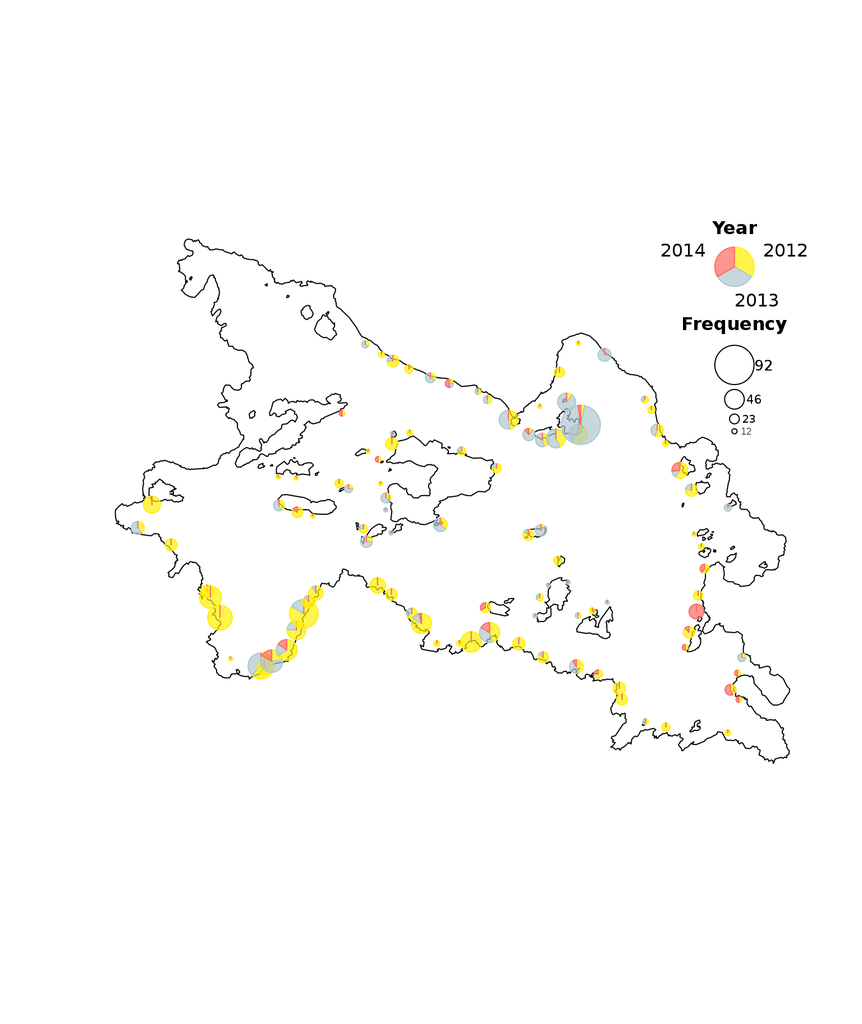

Next I plotted the data from the bubble pie graph and created a sorted horizontal frequency distribution to get a better idea of use among sites.

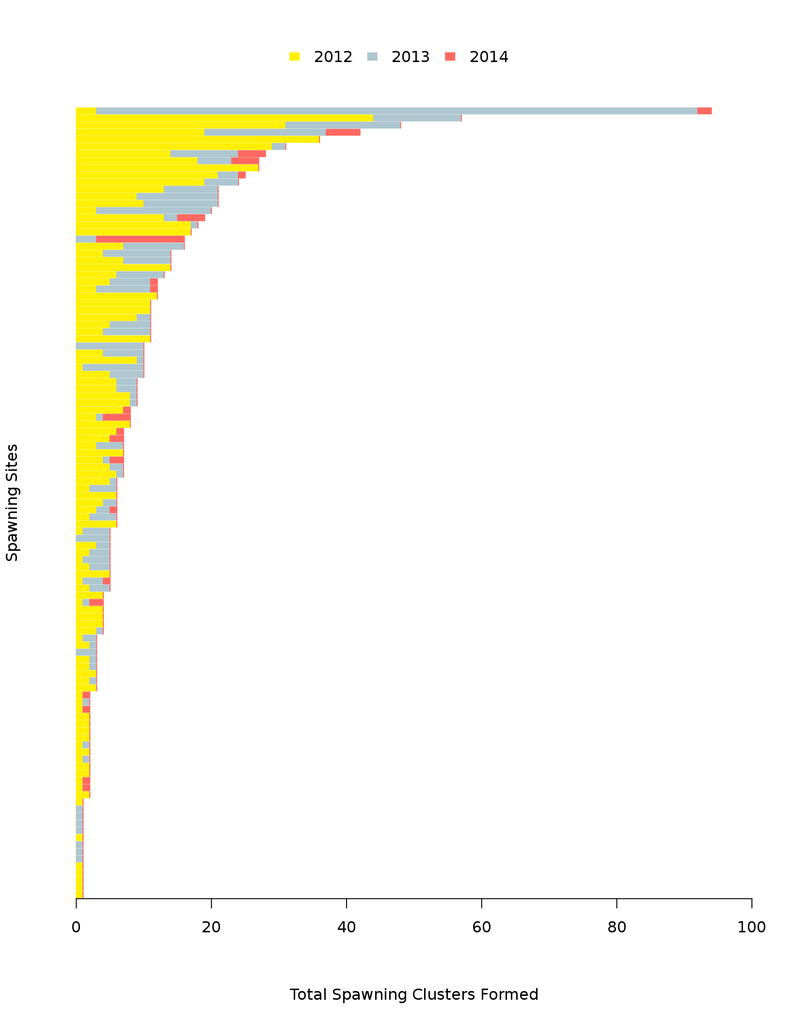

Next I created a series of bubble plots for each year where the bubble size represents frequency of use in that year.

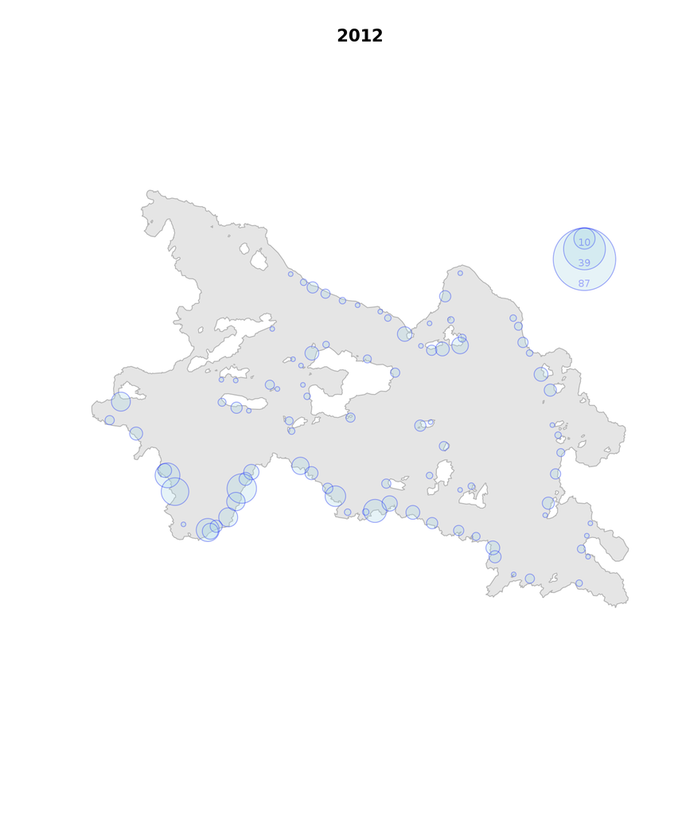

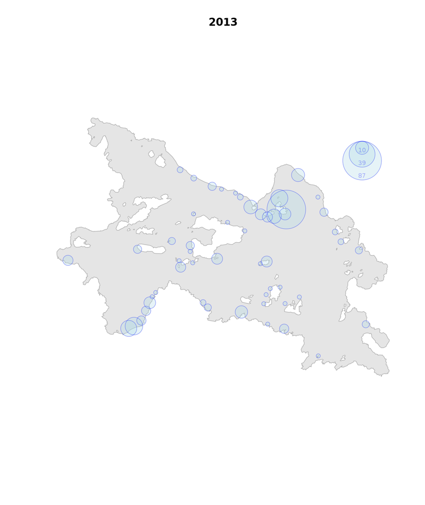

It is a tough to see the frequency bubbles in 2014, but I wanted to maintain the same scale as the previous years.

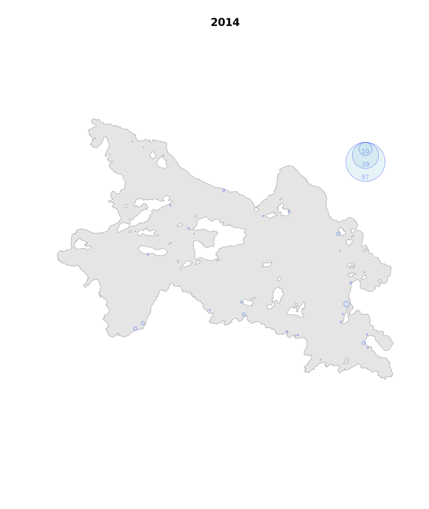

| Year | Sex | n | Daily Displacement | Std. Dev. | Persistence Index | Std. Dev. | Accel | Std. Dev. |
| --- | --- | --- | --- | --- | --- | --- | --- | --- |
| 2012 | F | 1 | 10025.49 | 4622.31 | 0.21 | 0.14 | NaN | NaN |
| 2012 | M | 4 | 8731.34 | 4387.93 | 0.09 | 0.21 | NaN | NaN |
| 2012 | U | 23 | 8833.05 | 4600.00 | 0.17 | 0.18 | NaN | NaN |
| 2013 | F | 6 | 8498.93 | 3922.81 | 0.18 | 0.17 | 0.38 | 0.18 |
| 2013 | M | 9 | 5955.44 | 3772.56 | 0.05 | 0.21 | 0.50 | 0.28 |
| 2013 | U | 14 | 5325.44 | 4423.99 | 0.06 | 0.32 | NaN | NaN |
| 2014 | F | 3 | 6773.38 | 4905.83 | 0.11 | 0.20 | 0.33 | 0.10 |
| 2014 | M | 5 | 4348.52 | 5143.83 | -0.12 | 0.36 | 0.57 | 0.24 |
| 2014 | U | 10 | 2877.50 | 2954.17 | -0.07 | 0.33 | NaN | NaN |

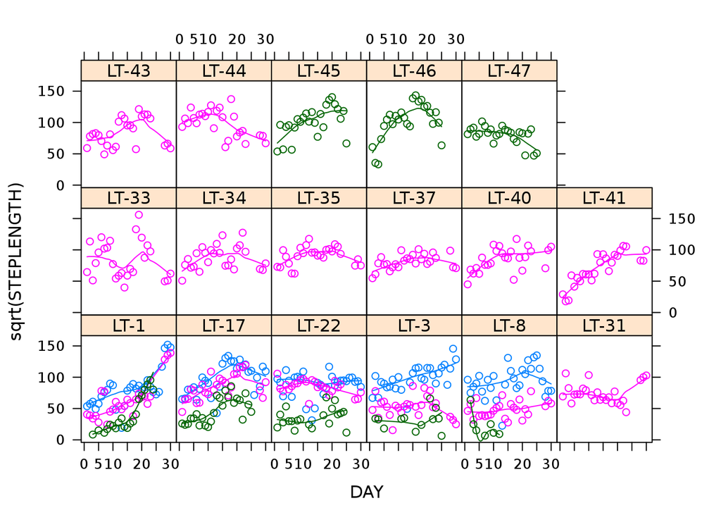

Chisq

Df

Pr(>Chisq)

SEX

2.651570

1

0.1034477

cDAY

21.963218

1

0.0000028

I(cDAY^2)

8.987048

1

0.0027190

YEAR

84.035349

2

0.0000000

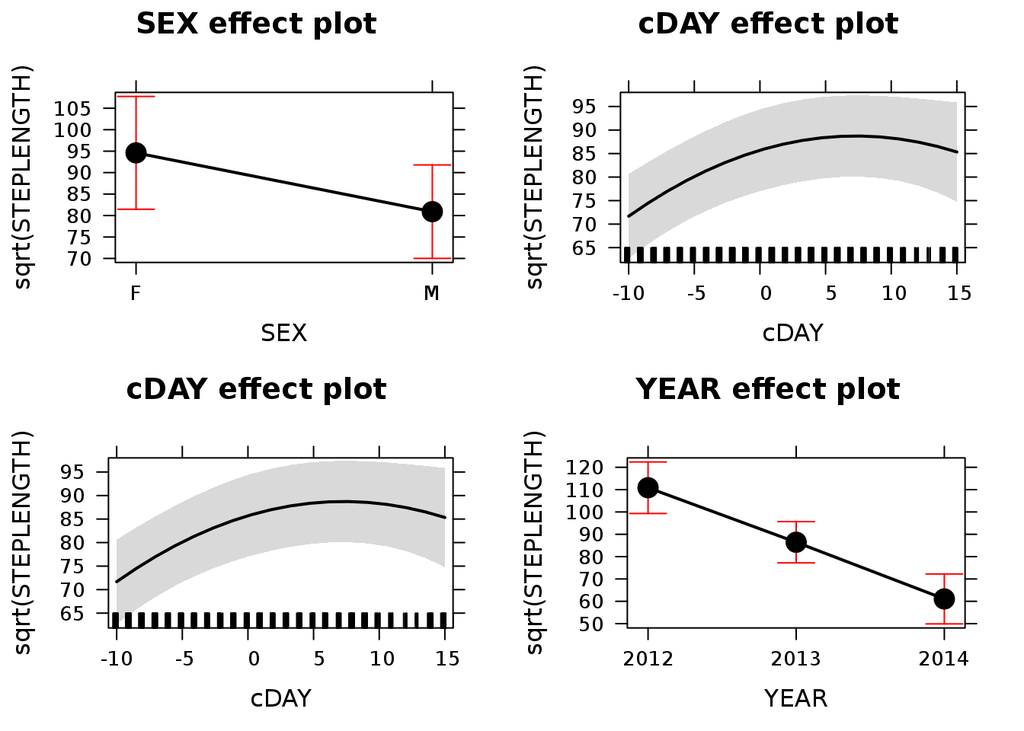

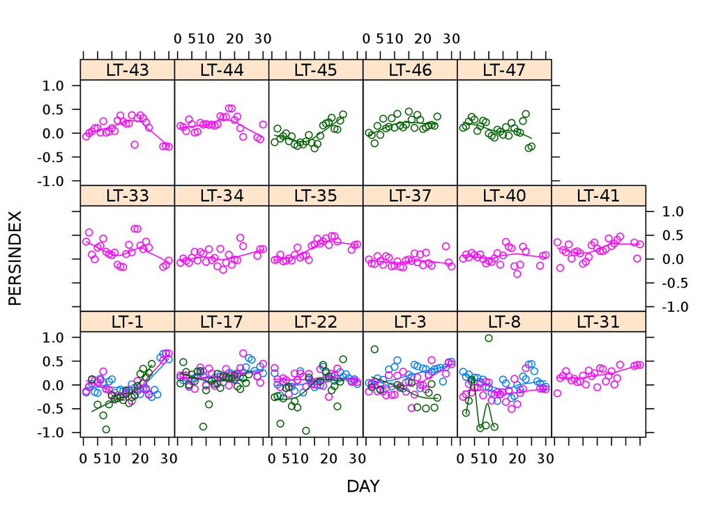

Chisq

Df

Pr(>Chisq)

SEX

15.57477

1

0.0000793

cDAY

16.03111

1

0.0000623

I(cDAY^2)

2.36845

1

0.1238099

YEAR

23.99317

2

0.0000062

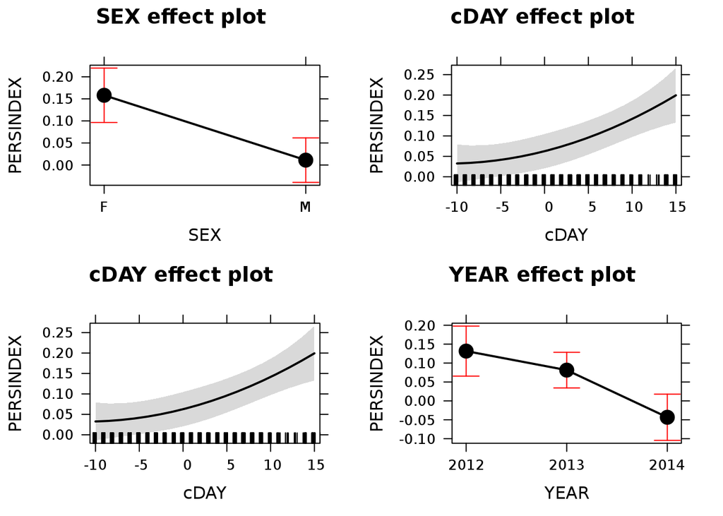

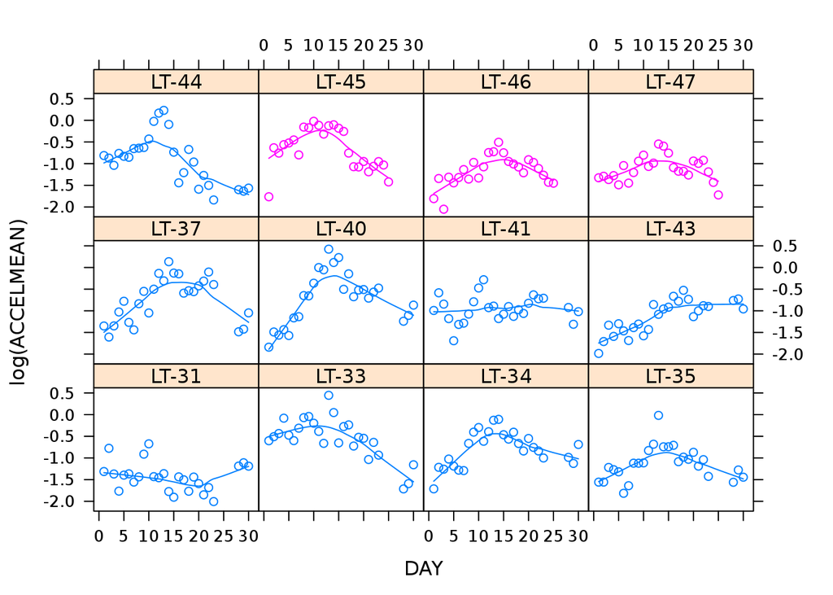

Chisq

Df

Pr(>Chisq)

SEX

3.9062208

1

0.0481077

cDAY

2.4116034

1

0.1204390

I(cDAY^2)

24.7085688

1

0.0000007

YEAR

0.7516694

1

0.3859482

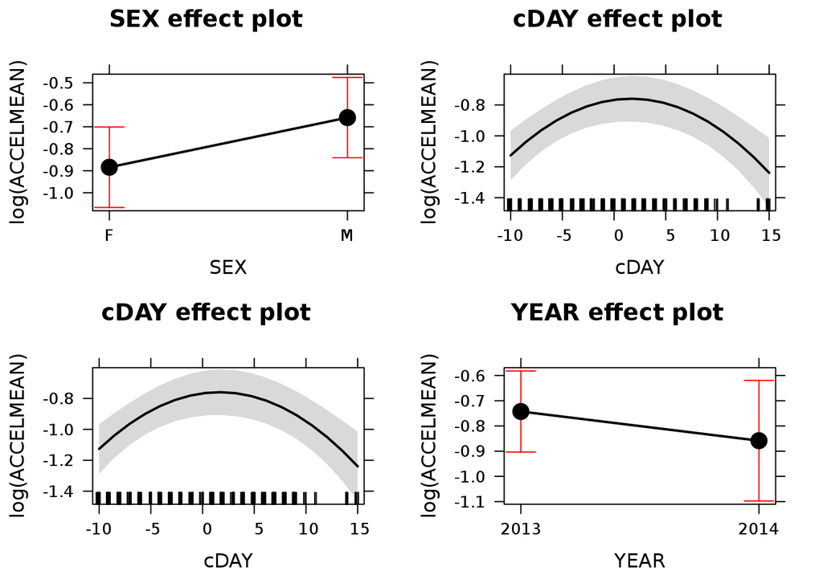